# 1.1 The Journey from Traditional BI to Modern Analytics

## Modal Views and Special Interfaces

Analytics+ includes several special modal views and interfaces:

### Chart Selection Gallery

The chart gallery provides a visual way to select visualization types:

- **Category Navigation**: Browse by chart category

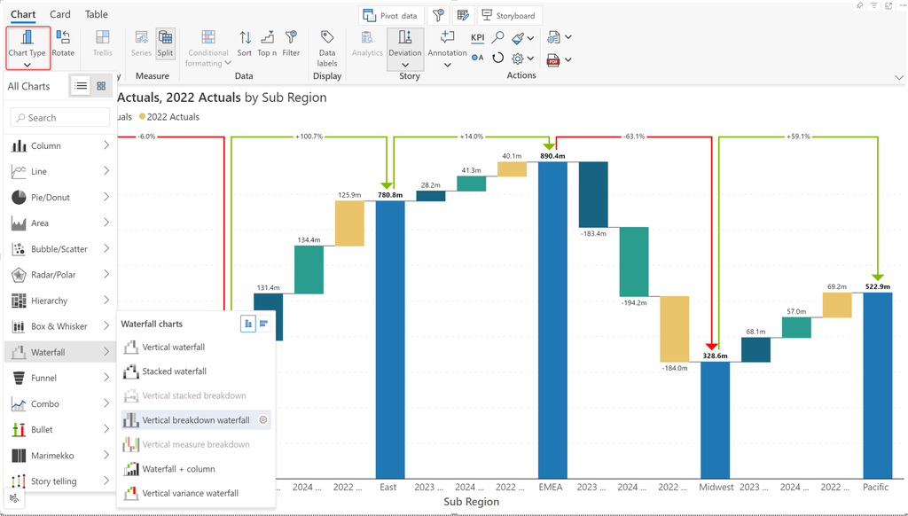

Category Navigation

- **Preview Thumbnails**: See miniature examples of each chart type

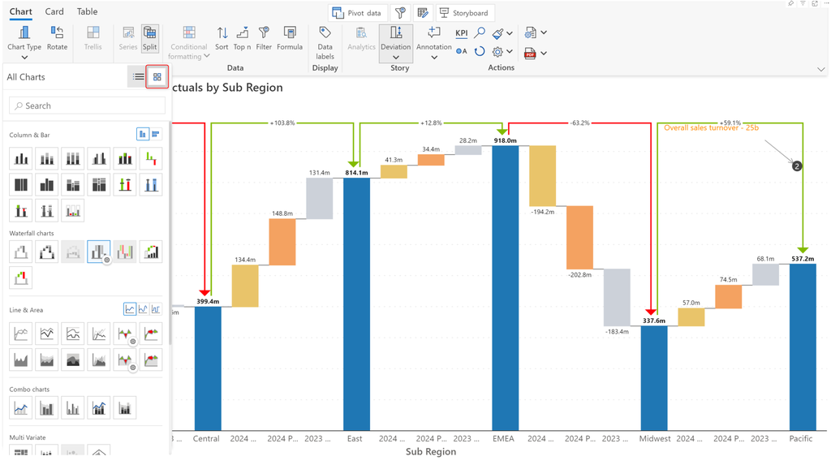

thumbnails

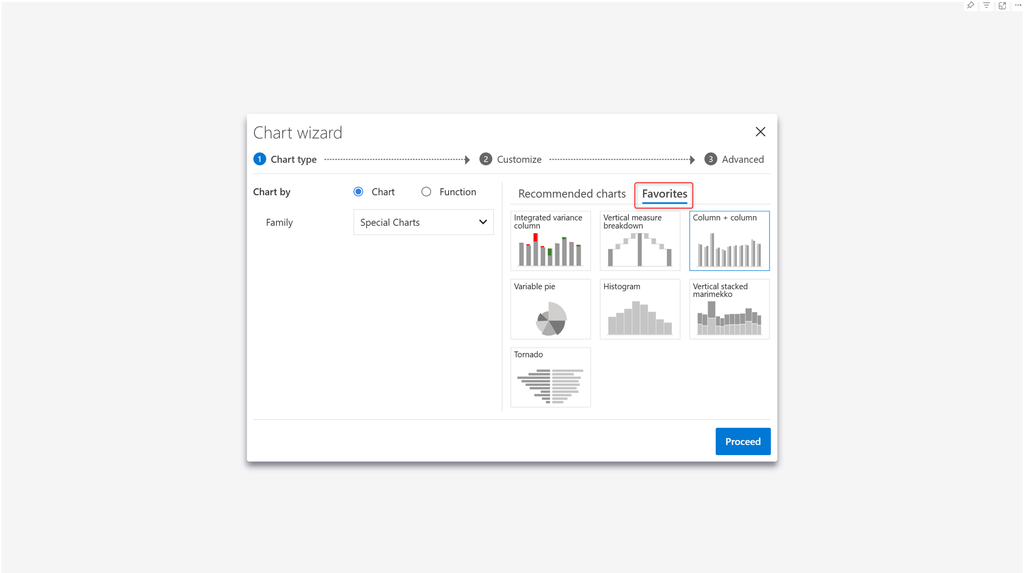

favorites

- **Search Function**: Find charts by name or description

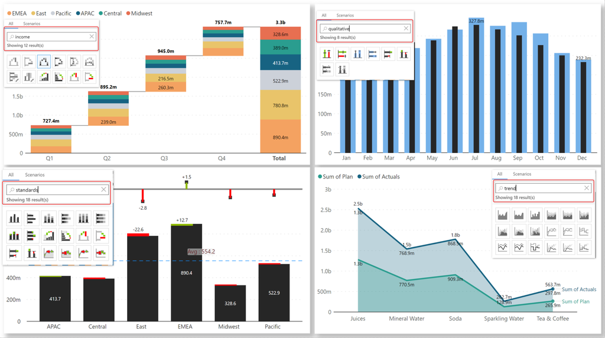

search

- **Data Preview**: See how your data would look in different chart types
- **Recommended Charts**: Suggestions based on your data structure or business scenario

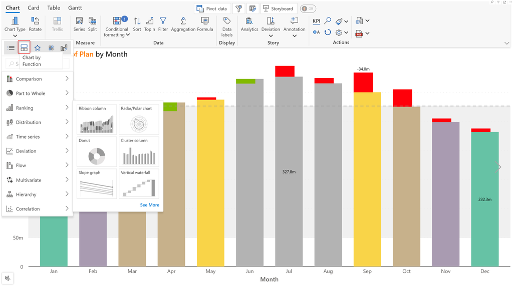

scenario based selection

- **Detailed Information**: Access details about each chart type’s purpose and requirements

This gallery simplifies the process of selecting from the 100+ available chart types.

### Formula Editor

The formula editor provides an environment for creating calculated measures within the Analytics+ visual:

- **Expression Field**: Area to enter your formula
- **Field References**: Easy insertion of data field references
- **Error Checking**: Real-time validation of formula syntax

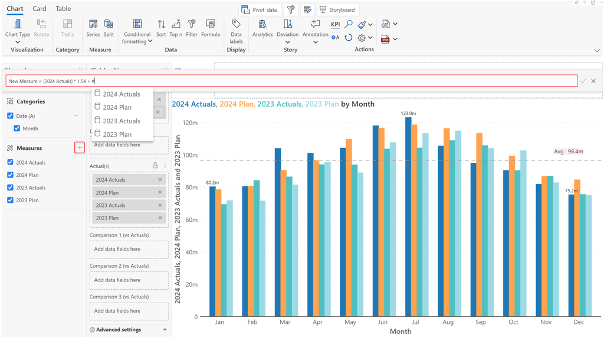

Formula editor

This specialized editor makes creating calculations more accessible to business users, without having to modify the underlying dataset.

### KPI Template Gallery

The KPI template gallery allows you to apply KPI presets in a single click:

- **Category Browsing**: Explore templates by type - Simple and Variance presets

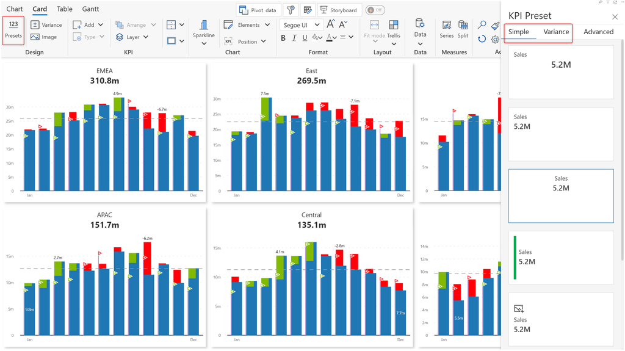

Category browsing

- **Preview Images**: See visual examples of each template

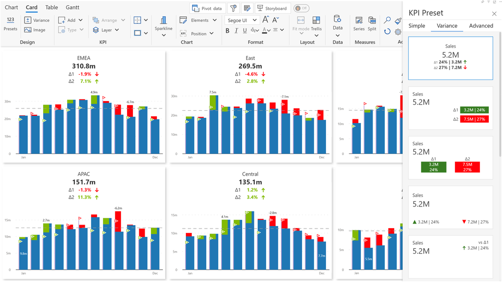

Preview images

- **Customization Options**: Modify templates to suit your needs
- **Sharing Features**: Use the Import Preset option to re-use and share templates across the organization

[figure not shown]

Import presets

This gallery accelerates development by leveraging pre-built visualization designs.

Understanding the Inforiver Analytics+ interface architecture and navigation principles is the foundation for effective use of the platform. As you become familiar with these elements, you’ll navigate the system more efficiently and take full advantage of its extensive visualization and analytical capabilities.

In the next section, we’ll explore how Analytics+ integrates with the broader Power BI workflow, ensuring a seamless experience for users working within the Microsoft ecosystem.

# 2.5 Integration with Power BI Workflow

Inforiver Analytics+ is designed to function as a seamless extension of Microsoft Power BI rather than a separate solution. This deep integration ensures that Analytics+ enhances the Power BI workflow without disrupting established processes or requiring users to learn entirely new systems. This section explores the various integration points between Analytics+ and Power BI, highlighting how the two solutions work together throughout the analytics lifecycle.

## Architectural Integration

At its core, Inforiver Analytics+ is implemented as a certified Power BI custom visual, providing deep architectural integration:

- **Custom Visual Framework**: Built on Microsoft’s Power BI custom visual API
- **Runtime Environment**: Executes within Power BI’s secure sandbox environment
- **Resource Management**: Integrated with Power BI’s memory and processing allocation
- **Security Model**: Inherits Power BI’s security context and access control
- **Update Cycle**: Coordinated with Power BI’s release cadence and compatibility requirements
- **API Alignment**: Leverages supported Power BI interfaces and communication channels
- **Certification Compliance**: Adheres to Microsoft’s certification requirements for enterprise use

This architectural approach ensures that Analytics+ behaves as a native component of Power BI while extending its capabilities beyond what’s available out-of-the-box.

## Data Integration

Analytics+ seamlessly connects with Power BI’s data layer:

### Data Source Compatibility

- **Dataset Access**: Direct access to Power BI datasets without additional data transfers
- **Data Model Respect**: Honors relationships and structures defined in the Power BI data model
- **Incremental Refresh**: Works with Power BI’s incremental refresh capabilities
- **Composite Models**: Compatible with composite models combining multiple data sources
- **DirectQuery Support**: Functions in both import and DirectQuery modes
- **Dataflows Integration**: Works with data prepared through Power BI dataflows
- **On-Premises Gateway**: Compatible with on-premises data gateway for accessing local data sources

### Data Transformation Compatibility

- **Power Query Integration**: Works with data transformed through Power Query
- **Calculated Columns**: Access to calculated columns defined in the data model
- **Measures Utilization**: Leverages DAX measures defined in the Power BI dataset
- **Hierarchies Support**: Respects hierarchies defined in the data model
- **Row-Level Security**: Honors RLS rules defined in Power BI
- **Data Categorization**: Respects data category definitions (e.g., geography, images)
- **Display Formatting**: Inherits default formatting defined in the data model

## Visual Integration

As a visual element within Power BI reports, Analytics+ works harmoniously with other aspects of the Power BI visual layer:

### Report Canvas Integration

- **Canvas Placement**: Functions as a standard visual element on the report canvas
- **Resize and Position**: Supports standard sizing and positioning controls
- **Z-Order Management**: Works with layering and front/back ordering
- **Group Membership**: Can be included in visual groups
- **Layout Containers**: Compatible with layout containers like vertical and horizontal slicers
- **Bookmark States**: States can be captured in Power BI bookmarks
- **Selection Pane**: Appears in and can be managed through the selection pane

### Theme Integration

- **Theme Inheritance**: Automatically adopts current Power BI theme colors
- **Organizational Themes**: Compatible with custom organizational themes
- **Theme Variables**: Respects theme variables for consistent report appearance
- **Contrast Modes**: Adapts to high contrast mode settings
- **Font Settings**: Inherits font family and base size settings
- **Background Effects**: Respects background settings and transparency
- **Border Styles**: Coordinated with theme-defined border settings

### Interaction Integration

- **Selection State**: Coordinates selection state with other visuals
- **Cross-Filtering**: Participates in Power BI’s cross-filtering experience
- **Cross-Highlighting**: Supports cross-highlighting from other visuals
- **Tooltips**: Compatible with Power BI’s tooltip system
- **Drill-Through**: Supports drill-through to other report pages
- **Q&A Integration**: Can be used with Power BI’s Q&A visual
- **Spotlight**: Works with Power BI’s spotlight feature for emphasis

## Filter Integration

Analytics+ participates fully in Power BI’s filtering ecosystem:

### Filter Consumption

- **Page Filters**: Responds to page-level filters
- **Report Filters**: Honors report-level filters
- **Visual Filters**: Accepts visual-level filters
- **Slicer Interaction**: Responds to slicer selections
- **Timeline Slicer**: Works with timeline slicers for date filtering
- **Sync Slicers**: Compatible with synced slicers across pages
- **Filter Pane**: Visible and configurable in the filters pane

### Filter Generation

- **Visual Interactions**: Can filter other visuals when configured
- **Interaction Settings**: Controlled through standard visual interaction settings
- **Hierarchical Filtering**: Supports hierarchical filter propagation
- **Bidirectional Filtering**: Works with bidirectional cross-filtering when defined in the model
- **Advanced Filtering**: Enables advanced filtering scenarios through visual interactions
- **Relative Date Filtering**: Compatible with relative date filtering
- **Top N Filtering**: Supports top/bottom N filtering scenarios

## Workflow Integration

Beyond technical integration, Analytics+ fits seamlessly into Power BI’s end-to-end workflow:

### Development Workflow

- **Desktop Development**: Fully functional in Power BI Desktop development environment
- **Version Control**: Works with standard version control practices for Power BI files
- **Development Lifecycle**: Participates in standard development, testing, and deployment cycles
- **Template Integration**: Works with Power BI templates (.pbit files)
- **Design Patterns**: Supports established Power BI design patterns and best practices
- **Agile Methodology**: Compatible with agile development approaches for Power BI
- **Documentation**: Can be included in standard documentation processes and tools

### Deployment Workflow

- **Deployment Pipelines**: Compatible with Power BI deployment pipelines
- **Workspace Publishing**: Publishes normally to Power BI workspaces
- **App Distribution**: Functions in Power BI apps distributed to end users
- **Staged Rollout**: Supports staged rollout strategies
- **Update Propagation**: Updates flow through standard Power BI update processes
- **Migration Scripts**: Works with automated deployment and migration scripts
- **Tenant Settings**: Respects organizational tenant settings

### Collaboration Workflow

- **Shared Datasets**: Works with shared datasets across workspaces
- **Commenting**: Supports Power BI commenting and discussion features
- **Subscriptions**: Compatible with Power BI subscription distribution
- **Sharing**: Works with standard Power BI sharing mechanisms
- **Teams Integration**: Functions in Microsoft Teams embedded reports
- **Workspace Collaboration**: Supports collaborative workspace models
- **Notifications**: Works with Power BI notification framework

## Administration Integration

Analytics+ aligns with Power BI’s administration framework:

### Governance Integration

- **Admin Portal**: Manageable through standard Power BI admin portal
- **Usage Metrics**: Included in standard Power BI usage metrics
- **Audit Logs**: Actions appear in Power BI audit logs
- **Data Lineage**: Participates in data lineage tracking
- **Impact Analysis**: Included in Power BI impact analysis
- **Certification Process**: Supports dataset and report certification workflows
- **Information Protection**: Compatible with sensitivity labels and information protection

### Security Integration

- **Authentication**: Uses Power BI’s authentication mechanisms
- **Authorization**: Respects Power BI’s authorization model
- **Row-Level Security**: Enforces RLS rules defined in Power BI
- **Object-Level Security**: Honors object-level security settings
- **Conditional Access**: Works with conditional access policies
- **Tenant Isolation**: Maintains appropriate tenant boundaries
- **Data Protection**: Follows Power BI’s data protection mechanisms

### Licensing Integration

- **Service Plans**: Visibility respects user service plans
- **Premium Features**: Adheres to Premium vs. Pro feature availability
- **Capacity Management**: Works within Premium capacity resource governance
- **License Enforcement**: Respects Power BI license enforcement
- **Feature Discovery**: Shows appropriate features based on license level
- **Upgrade Paths**: Supports smooth upgrade experiences between tiers
- **Trial Access**: Compatible with Power BI trial processes

## Performance Integration

Analytics+ is designed to work harmoniously with Power BI’s performance optimization framework:

### Performance Monitoring

- **Performance Inspector**: Compatible with Power BI Performance Analyzer
- **Query Diagnostics**: Works with Power BI query diagnostics
- **Timing Insights**: Provides timing information for diagnostics
- **Resource Utilization**: Optimized for efficient resource usage within Power BI
- **Refresh Metrics**: Included in refresh performance monitoring
- **Bottleneck Identification**: Helps identify performance bottlenecks
- **Performance Recommendations**: Aligns with Power BI performance best practices

### Performance Optimization

- **Caching Mechanisms**: Works with Power BI’s caching framework
- **Query Folding**: Supports query folding for compatible operations
- **Parallel Processing**: Takes advantage of parallel query processing
- **Incremental Processing**: Compatible with incremental data refresh
- **Query Reduction**: Minimizes unnecessary query generation
- **Rendering Optimization**: Optimized rendering within Power BI’s visual framework
- **Resource Sharing**: Efficient sharing of resources with other visuals

## Mobile Integration

Analytics+ delivers a responsive experience across Power BI’s mobile ecosystem:

- **Mobile App Support**: Functions in Power BI mobile apps
- **Responsive Design**: Adapts to different screen sizes and orientations
- **Touch Optimization**: Supports touch-based interactions
- **Mobile Layout**: Compatible with Power BI’s mobile layout designer
- **Offline Viewing**: Supports offline report viewing in mobile apps
- **Mobile Notifications**: Works with Power BI mobile notification system
- **Mobile Formatting**: Adjusts visualization for optimal mobile viewing

## Embedded Integration

For organizations using Power BI embedded scenarios, Analytics+ provides comprehensive support:

- **Power BI Embedded**: Functions in Power BI Embedded scenarios
- **Embedded Analytics**: Compatible with embedded analytics in custom applications
- **Embed Configuration**: Respects embed configuration settings
- **JavaScript SDK**: Works with Power BI JavaScript SDK
- **iframe Embedding**: Supports iframe embedding techniques
- **URL Filters**: Compatible with URL filtering parameters
- **Secure Embedding**: Maintains security in embedded contexts

## Extended Integration Points

Beyond standard integration, Analytics+ offers several extended integration capabilities:

### Export Integration

- **Excel Export**: Enhanced Excel export capabilities beyond standard Power BI
- **PDF Export**: Advanced PDF formatting and export options
- **PowerPoint Export**: Optimized export to PowerPoint presentations
- **Image Export**: High-resolution image export with customization options
- **Data Export**: Flexible data export with formatting preservation
- **Scheduled Exports**: Compatible with scheduled export solutions
- **Custom Format Export**: Export to specialized formats when required

### Writeback Integration

- **Data Input**: Provides data input capabilities within the Power BI framework
- **Planning Workflow**: Integrates planning and forecasting into Power BI reports
- **What-if Scenarios**: Enhanced what-if capabilities beyond native features
- **Approval Process**: Support for approval workflows within Power BI
- **Revision Tracking**: Version management for data changes
- **Validation Rules**: Sophisticated data validation within Power BI
- **Audit Trail**: Tracking of changes made through writeback

## Integration Best Practices

To maximize the value of Analytics+ within your Power BI workflow, consider these integration best practices:

### Planning Integration

- **Discovery Workshop**: Identify integration points and requirements early
- **Pilot Projects**: Test integration in controlled environments first
- **Integration Architecture**: Design a cohesive architecture leveraging both platforms
- **User Journey Mapping**: Map end-to-end user journeys across both solutions
- **Integration Standards**: Establish standards for consistent integration
- **Technical Prerequisites**: Ensure all technical prerequisites are met
- **Success Criteria**: Define clear criteria for successful integration

### Implementation Integration

- **Phased Approach**: Implement integration in manageable phases
- **Template Development**: Create templates that leverage integration points
- **Style Guide**: Develop a style guide for consistent visual appearance
- **Integration Testing**: Thoroughly test all integration points
- **Performance Benchmarking**: Establish performance benchmarks
- **Documentation**: Document integration patterns and solutions
- **Knowledge Transfer**: Ensure team understands integration capabilities

### Workflow Optimization

- **Process Redesign**: Optimize processes to leverage integration capabilities
- **Automation Opportunities**: Identify opportunities for workflow automation
- **Training Alignment**: Align training with integrated workflows
- **Feedback Loops**: Establish feedback mechanisms for continuous improvement
- **KPI Tracking**: Track KPIs related to integration benefits
- **Use Case Expansion**: Systematically expand to new integration use cases
- **Community Building**: Build internal community around integrated solutions

## Common Integration Scenarios

Several integration scenarios demonstrate the power of combining Analytics+ with Power BI:

### Financial Reporting & Planning

- **Integrated Reporting**: Enhanced financial visualizations with native Power BI filters
- **Planning Cycle**: Budgeting and forecasting within Power BI environment
- **Variance Analysis**: Advanced variance visualization integrated with overall dashboards
- **Planning Controls**: Planning controls coordinated with reporting views
- **Approval Workflow**: Planning approval workflow within Power BI
- **Financial Storytelling**: Enhanced financial narrative with IBCS standards
- **Financial Consolidation**: Complex consolidation with writeback capabilities

### Sales Analytics

- **Performance Dashboards**: Enhanced sales visualizations with native slicers
- **Territory Planning**: Territory planning integrated with results analysis
- **Quote Creation**: Quote generation workflow within analytics environment
- **Pipeline Visualization**: Advanced pipeline visualization beyond native capabilities
- **Sales Forecasting**: Integrated forecasting with historical analysis
- **Customer Segmentation**: Enhanced segmentation visualization
- **Commission Calculation**: Commission scenarios and calculation

### Operational Reporting

- **KPI Tracking**: Enhanced KPI visualizations integrated with operational metrics
- **Resource Planning**: Resource planning within reporting environment
- **Process Monitoring**: Advanced process visualization with Power BI data
- **Scenario Modeling**: Operational scenario modeling with writeback
- **Quality Analysis**: Enhanced quality visualization beyond native capabilities
- **Capacity Planning**: Integrated capacity planning and monitoring
- **Supply Chain Visibility**: Enhanced supply chain visualization

## Future Integration Roadmap

The integration between Analytics+ and Power BI continues to evolve through:

- **Fabric Integration**: Deeper integration with Microsoft Fabric capabilities
- **AI Builder Alignment**: Coordination with Power BI’s AI capabilities
- **Copilot Integration**: Future alignment with Microsoft Copilot features
- **DataMart Connectivity**: Enhanced connections with Power BI DataMarts
- **Event-Based Integration**: Advanced event-based interactions
- **Composite Modeling**: Enhanced support for complex composite models
- **DirectLake Integration**: Support for emerging DirectLake pattern

By thoroughly understanding the integration between Inforiver Analytics+ and Power BI, organizations can maximize the value of both investments while maintaining a cohesive, streamlined analytics workflow. This integration approach enables users to leverage the enhanced capabilities of Analytics+ while working within the familiar, enterprise-grade environment of Microsoft Power BI.

In the next section, we’ll explore a practical case study of how an organization successfully implemented Analytics+ within their Power BI environment to solve complex business challenges.

# 2.6 CASE STUDY: Merck’s Transition from Excel-Based Forecasting

This case study examines how Merck, a global pharmaceutical leader, transformed its financial forecasting processes by transitioning from complex Excel-based solutions to Inforiver Analytics+ within Microsoft Power BI. Their journey illustrates the practical application of the concepts covered in previous sections and provides valuable insights for organizations facing similar challenges.

## Organization Background

Merck & Co., Inc. (known as MSD outside the United States and Canada) is one of the largest pharmaceutical companies in the world, with approximately 74,000 employees and operations in more than 140 countries. The company develops and produces medicines, vaccines, biologic therapies, and animal health products.

Key organizational facts relevant to this case study:

- **Annual Revenue**: Approximately $59 billion (2023)
- **R&D Investment**: Over $13.5 billion annually
- **Product Portfolio**: 80+ prescription products across multiple therapeutic areas
- **Global Presence**: Manufacturing facilities and research centers worldwide
- **Financial Operations**: Complex multi-currency, multi-market financial tracking and forecasting

## Initial Situation and Challenges

Prior to implementing Analytics+, Merck’s financial forecasting environment was characterized by:

### Excel-Centric Reporting Ecosystem

- **Complex Workbooks**: Highly sophisticated Excel models with thousands of formulas
- **Manual Integration**: Multiple data sources requiring manual consolidation
- **Version Control Issues**: Proliferation of spreadsheet versions with inconsistent updates
- **Limited Collaboration**: Siloed analysis with sequential rather than parallel workflows
- **Time-Intensive Processes**: Financial analysts spending 60-70% of time on data preparation
- **Governance Concerns**: Limited audit trails and documentation of calculation methodologies
- **Scale Limitations**: Performance degradation with large datasets
- **Visualization Constraints**: Basic Excel charts lacking interactive capabilities

### Business Impact of Existing Approach

These technical limitations translated into several business challenges:

- **Forecast Cycle Time**: Monthly forecasting requiring 12-15 business days to complete
- **Error Susceptibility**: Manual processes introducing data quality issues
- **Analysis Depth**: Limited time for value-added analysis due to data preparation burden
- **Decision Latency**: Delayed insights impacting strategic and operational decisions
- **Regional Inconsistency**: Different approaches across geographical markets
- **Scenario Limitations**: Restricted ability to model multiple business scenarios
- **Collaboration Barriers**: Difficulty in gathering inputs from multiple stakeholders

### Attempted Solutions

Before turning to Analytics+, Merck had attempted several approaches:

- **Excel Automation**: VBA macros and Power Query to streamline processes
- **Native Power BI**: Initial implementation of standard Power BI visuals
- **Custom Development**: Proprietary web-based forecasting tools
- **Alternative BI Tools**: Evaluation of other business intelligence platforms

While each approach offered partial improvements, none delivered the comprehensive solution needed to transform the forecasting process while maintaining the analytical flexibility that business users valued in Excel.

## Decision Process and Selection Criteria

Merck’s journey to selecting Analytics+ included a structured evaluation process:

### Key Requirements

The finance transformation team established these critical requirements:

1. **Excel-Like Functionality**: Familiar formulas and calculation capabilities
2. **Enterprise Scalability**: Ability to handle global data volumes
3. **Process Integration**: Seamless fit with existing Power BI investments
4. **Visual Standardization**: Consistent visualization across markets
5. **Collaborative Features**: Multi-user input and concurrent analysis
6. **Security Controls**: Robust governance and access management
7. **Performance**: Speed and responsiveness with complex calculations
8. **Analysis Flexibility**: Support for ad-hoc scenario modeling
9. **Mobile Compatibility**: Access for executives on multiple devices
10. **Implementation Timeline**: Rapid deployment and quick wins

### Evaluation Process

Merck conducted a comprehensive evaluation involving:

- **Proof of Concept**: Four-week trial with actual financial data
- **User Testing**: Hands-on evaluation by financial analysts
- **Technical Assessment**: IT evaluation of security and integration
- **Vendor Comparison**: Side-by-side comparison with alternatives
- **Total Cost Analysis**: Implementation, licensing, and maintenance projections
- **Reference Checks**: Discussions with existing Analytics+ customers

The combination of Excel-like formula capabilities, superior performance with large datasets, and seamless Power BI integration ultimately led to the selection of Inforiver Analytics+.

## Implementation Approach

Merck adopted a phased implementation strategy:

### Phase 1: Global Template Development (3 Months)

- **Core Team Formation**: Cross-functional team of finance, IT, and business representatives
- **Process Mapping**: Documentation of existing forecasting workflows
- **Data Architecture**: Design of standardized data model
- **Template Creation**: Development of global forecasting templates
- **Formula Migration**: Translation of Excel formulas to Analytics+ formulas
- **Initial Validation**: Testing with representative data samples

### Phase 2: Pilot Implementation (2 Months)

- **Market Selection**: Two representative markets (one large, one mid-sized)
- **Controlled Rollout**: Limited user group with hands-on support
- **Parallel Processing**: Running new system alongside existing process
- **Performance Testing**: Validation of system performance
- **User Feedback Collection**: Structured feedback gathering
- **Template Refinement**: Adjustments based on pilot experience

### Phase 3: Global Deployment (6 Months)

- **Regional Sequencing**: Phased rollout across geographic regions
- **Training Program**: Comprehensive training for all user types
- **Support Structure**: Establishment of support mechanisms
- **Legacy Transition**: Gradual retirement of Excel-based processes
- **Governance Implementation**: Rollout of standards and governance framework
- **Enhancement Process**: Structure for ongoing improvements

## Technical Architecture

The implemented solution featured this technical architecture:

### Data Layer

- **Source Systems**: SAP, CRM, and other enterprise systems
- **Data Warehouse**: Azure Synapse Analytics for consolidated data
- **Data Transformation**: Azure Data Factory and Power Query
- **Data Model**: Star schema with standardized dimensions
- **Refresh Schedule**: Daily automated data refreshes
- **Historical Storage**: 36 months of historical data plus forecast periods

### Analytics Layer

- **Platform**: Microsoft Power BI Premium
- **Visualization**: Inforiver Analytics+ within Power BI
- **Semantic Layer**: Power BI dataset with defined relationships
- **Calculation Engine**: Analytics+ formula engine for business calculations
- **Version Control**: Multi-version forecast scenarios
- **Writeback Mechanism**: Input capabilities for forecasting
- **Integration Points**: Finance systems, planning tools, reporting platforms

### User Experience Layer

- **Report Types**: Strategic dashboards, operational reports, input forms
- **Chart Types**: Variance charts, forecasting visualizations, trend analysis
- **Mobile Experience**: Optimized views for executive consumption
- **Export Capabilities**: PowerPoint and Excel integration
- **Notification System**: Alerts for forecast updates and deadlines
- **Collaboration Features**: Commentary and discussion threads

### Security Framework

- **Authentication**: Microsoft Entra ID (formerly Azure AD)
- **Authorization**: Row-level security based on organizational hierarchy
- **Data Protection**: Sensitivity labeling for confidential information
- **Audit Trail**: Comprehensive logging of changes
- **Access Control**: Role-based permissions for different user types
- **Compliance Features**: Regulatory reporting requirements coverage

## Key Implementation Challenges

The transformation journey encountered several significant challenges:

### Technical Challenges

- **Formula Complexity**: Migrating sophisticated Excel formulas to Analytics+
- **Performance Tuning**: Optimizing large datasets for responsive analysis
- **Integration Points**: Connecting with legacy financial systems
- **Custom Calculations**: Implementing market-specific calculation requirements
- **Data Refresh Cycles**: Balancing freshness with performance

### Organizational Challenges

- **Excel Attachment**: Overcoming user preference for familiar Excel environment
- **Process Redesign**: Rethinking processes to leverage new capabilities
- **Skill Gaps**: Addressing varying levels of data literacy
- **Change Management**: Building buy-in across global teams
- **Governance Evolution**: Updating policies for the new environment

The implementation team addressed these challenges through a combination of technical solutions, iterative development, and comprehensive change management.

## User Adoption Strategy

Merck’s adoption strategy focused on:

### Training Program

- **Role-Based Training**: Tailored to different user personas
- **Blended Learning**: Combination of live sessions and on-demand content
- **Hands-On Workshops**: Practical exercises with real business scenarios
- **Quick Reference Materials**: Guides and job aids for common tasks
- **Advanced Training**: Deep dives for power users and administrators
- **Continuous Education**: Regular feature updates and refreshers

### Change Management

- **Executive Sponsorship**: Visible support from finance leadership
- **Champions Network**: Super-users in each region providing peer support
- **Success Metrics**: Clear definition and tracking of adoption metrics
- **Communication Plan**: Regular updates on rollout progress
- **Feedback Mechanisms**: Structured channels for user input
- **Recognition Program**: Acknowledging early adopters and innovators

## Results and Benefits

After 18 months of full implementation, Merck achieved significant improvements:

### Quantitative Benefits

- **Forecast Cycle Reduction**: From 12-15 days to 4-5 days per month
- **Analysis Time Increase**: Analysts now spending 70% on analysis vs. 30% on data preparation
- **Error Reduction**: 62% decrease in reported data inconsistencies
- **Scenario Expansion**: Ability to evaluate 5-7 scenarios vs. previous 2-3
- **Version Control**: 100% elimination of version confusion issues
- **Data Volume Handling**: Processing 3x the data points without performance degradation
- **Time Savings**: Approximately 2,400 analyst hours saved per month globally

### Qualitative Benefits

- **Decision Quality**: More informed business decisions with enhanced analytics
- **Standardization**: Consistent global approach to forecasting
- **Transparency**: Improved visibility into forecast assumptions and calculations
- **Collaboration**: Enhanced cross-functional and cross-regional cooperation
- **User Satisfaction**: 85% of users reporting preference for new system over Excel
- **Governance**: Stronger audit trails and calculation documentation
- **Strategic Focus**: Greater analyst focus on insights vs. data manipulation

### Key Analytics+ Capabilities Leveraged

Several specific Analytics+ capabilities proved particularly valuable:

- **Visual Formula Engine**: Allowing Excel-like calculations without DAX complexity
- **Data Point Capacity**: Handling 30K+ data points for comprehensive analysis
- **IBCS Visualizations**: Standardized financial variance charts
- **Small Multiples**: Comparative analysis across products and regions
- **Planning Integration**: Seamless forecasting and reporting in one environment
- **Export Features**: Professional outputs for executive presentations
- **Mobile Optimization**: Executive access to forecasts while traveling

## Lessons Learned and Best Practices

Merck’s experience yielded several valuable insights:

### Success Factors

- **Process First, Technology Second**: Focusing on process optimization before tool implementation
- **Excel Bridge Strategy**: Maintaining Excel export capabilities during transition
- **Phased Implementation**: Incremental approach with defined success criteria
- **User Involvement**: Early and continuous user engagement in design
- **Performance Prioritization**: Emphasis on system responsiveness for user acceptance
- **Template Standardization**: Global templates with controlled local customization
- **Technical Documentation**: Comprehensive documentation of formulas and calculations
- **Executive Dashboards**: High-visibility wins with leadership reporting

### Implementation Recommendations

Based on their experience, Merck recommends:

1. **Start Small**: Begin with a well-defined use case for quick wins
2. **Parallel Running**: Maintain existing processes until new system is proven
3. **Leverage Templates**: Use pre-built Analytics+ templates as starting points
4. **Invest in Training**: Comprehensive training tailored to different user roles
5. **Monitor Performance**: Regular performance reviews as data volumes grow
6. **Establish Governance**: Clear standards for visualization and calculations
7. **Capture Feedback**: Structured process for user feedback and enhancements
8. **Measure Success**: Define and track clear success metrics
9. **Plan for Evolution**: Anticipate expanding capabilities over time

## Future Directions

Building on their success, Merck is expanding their Analytics+ implementation:

- **AI Integration**: Incorporating predictive analytics into forecasting
- **Expanded Use Cases**: Application to additional finance processes
- **Process Automation**: Further streamlining of the forecast workflow
- **Cross-Functional Expansion**: Extending to supply chain and commercial planning
- **External Sharing**: Selective forecast sharing with strategic partners
- **Advanced Analytics**: Deeper statistical analysis of forecast accuracy
- **Fabric Integration**: Leveraging Microsoft Fabric as it matures

## Conclusion

Merck’s transition from Excel-based forecasting to Inforiver Analytics+ demonstrates how organizations can successfully modernize complex financial processes while preserving the analytical flexibility that business users require. By combining a thoughtful implementation approach with powerful technology, Merck achieved significant improvements in efficiency, accuracy, and analytical depth.

This case study illustrates the practical application of concepts discussed throughout this chapter, from installation and integration to interface design and Power BI workflow alignment. It also highlights the importance of considering both technical and organizational factors when implementing advanced visualization and analytics solutions.

In the next chapter, we’ll explore the advanced visualization capabilities of Analytics+ in greater detail, examining the extensive chart library and standards-based approach to business communication.

# 3.1 Introduction to the Analytics+ Visualization Framework

Effective visualization is at the core of modern business analytics, enabling organizations to transform complex data into actionable insights. Inforiver Analytics+ offers a sophisticated visualization framework that goes far beyond the capabilities of native Power BI visuals, providing business users with the tools to create professional, standards-compliant visualizations without specialized technical skills. This chapter explores the extensive visualization capabilities of Analytics+, examining its comprehensive chart library, standards-based approach, and advanced interactive features.

Analytics+ has been built as a complete storytelling platform that enables even casual users to create engaging, dynamic dashboards and reports in a matter of minutes. The visual ships with five distinct modes, each with dedicated toolbars and customization options:

1. **Chart Mode**: Offers a diverse library of over 100 chart types including Waterfall, Marimekko, Bullet charts, and boxplots, suitable for virtually any data visualization scenario.
2. **Card Mode**: Provides KPI cards with embedded charts, text, and image support to showcase metrics in a compact, information-rich format.
3. **Table Mode**: Delivers a bird’s eye view of data categories and relationships with advanced tabular visualizations including small multiples tables.
4. **Gantt Mode**: Enables users to visualize task schedules, identify dependencies, allocate resources, and track deadlines with a best-in-class Gantt chart implementation.
5. **Storyboard Mode**: Allows rapid design of captivating dashboards with a single visual and a single query, incorporating charts, text, images, slicers, KPI cards, and tables without importing separate visuals.

Users can seamlessly switch between these modes, leveraging the specific capabilities of each to create comprehensive, interactive visualizations that communicate insights effectively.

## The Evolution of Business Visualization

Business visualization has evolved significantly over the past decade, moving from basic charts and graphs to sophisticated, interactive visual analysis tools. This evolution has been driven by several key factors:

- **Data Complexity Growth**: Increasing volumes and complexity of business data
- **Decision Speed Requirements**: Accelerating business cycles demanding faster insights
- **Visualization Best Practices**: Maturing standards for effective visual communication
- **User Expectations**: Rising expectations for intuitive, interactive experiences
- **Mobile Accessibility**: Need for visualization consumption across devices
- **Analytical Sophistication**: Growing demand for advanced analytical capabilities
- **Democratization of Analytics**: Expanding visualization access beyond specialists

Despite these advances, many organizations still struggle with visualization limitations in their business intelligence platforms, including restricted chart types, performance constraints, lack of standardization, and complex implementation requirements. These limitations often result in suboptimal visual communication, compromised analytical depth, and inefficient workflows as users resort to exporting data to other tools.

## The Analytics+ Visualization Philosophy

Inforiver Analytics+ approaches visualization with a distinct philosophy centered on several core principles:

### 1. Comprehensive Visual Language

Analytics+ provides a complete visual vocabulary for business communication through:

- **Extensive Chart Library**: 100+ chart types covering all major analytical scenarios
- **Standardized Visuals**: International Business Communication Standards (IBCS) certification
- **Flexible Customization**: Ability to tailor visualizations while maintaining standards
- **Visual Hierarchy**: Tools to establish clear information hierarchy in visualizations
- **Contextual Elements**: Support for annotations, reference lines, and explanatory components
- **Cohesive Design System**: Consistent visual language across all visualization types
- **Template Framework**: Reusable templates for standardized implementation

This comprehensive approach ensures that users have access to the right visualization type for any analytical situation without compromising on visual quality or standards.

### 2. Business User Empowerment

Analytics+ democratizes sophisticated visualization through:

- **No-Code Creation**: Visual configuration without programming requirements
- **Excel-Like Familiarity**: Leveraging common spreadsheet knowledge
- **Guided Selection**: Intelligent chart recommendation based on data characteristics
- **Direct Manipulation**: On-object interaction for intuitive editing
- **Simplified Controls**: Accessible configuration panels for complex visualization properties
- **Template-Based Starting Points**: Pre-built frameworks for common scenarios
- **Progressive Disclosure**: Advanced options revealed as needed

This approach enables business users to create professional visualizations without dependence on technical specialists, significantly accelerating the insight-to-action cycle.

### 3. Enterprise Performance

Analytics+ is built for enterprise-scale visualization needs:

- **Large Dataset Handling**: Support for 30,000+ data points versus native 3,500
- **Rendering Optimization**: Efficient visualization of complex charts
- **Interactive Performance**: Responsive interactions even with large datasets
- **Memory Management**: Optimized memory usage for stable performance
- **Mobile Responsiveness**: Effective visualization across device types
- **Enterprise Integration**: Seamless operation within corporate BI environments
- **Scalable Implementation**: From departmental to organization-wide deployment

This enterprise-grade performance ensures that visualization quality and responsiveness are maintained even in demanding enterprise environments with large, complex datasets.

### 4. Analytical Integration

Analytics+ treats visualization as an integral part of the analytical process:

- **Calculation Integration**: Direct connection between visualizations and analytical calculations
- **Interactive Analysis**: Dynamic visual exploration of data
- **Comparative Views**: Easy creation of multi-scenario visual comparisons
- **Statistical Visualization**: Built-in statistical visualization capabilities
- **Planning Visualization**: Integrated visualization of planning and forecasting data
- **Analytical Annotations**: Visual highlighting of analytical findings
- **Insight Extraction**: Tools to identify and emphasize key insights

This integrated approach ensures that visualization is not just about presentation but serves as a core analytical tool that helps users discover and communicate insights.

## Visualization Framework Architecture

The Analytics+ visualization framework is built on a multi-layer architecture designed for flexibility, performance, and standards compliance:

### Visualization Layer

The outermost layer that users directly interact with, comprising:

- **Chart Types**: The 100+ visualization options available to users
- **Templates**: Pre-configured visualization patterns
- **Style Library**: Visual styling and formatting options
- **Interaction Patterns**: Defined user interaction behaviors
- **Annotation System**: Tools for adding context and explanation
- **Layout Engine**: Control of visual element positioning and sizing
- **Responsive Framework**: Adaptation to different display environments

### Data Visualization Layer

The layer that transforms data into visual representations:

- **Visual Mapping Engine**: Translation of data values to visual properties
- **Scale Management**: Handling of axes, ranges, and data domains
- **Color Management**: Application of color schemes and palettes
- **Legend System**: Generation and management of visualization legends
- **Small Multiples Engine**: Creation of trellis/small multiples displays
- **Data Label Handler**: Positioning and formatting of data labels
- **Reference Elements**: Implementation of reference lines, bands, and points

### Analytical Layer

The layer that enhances visualizations with analytical capabilities:

- **Statistical Functions**: Built-in statistical calculations
- **Trend Analysis**: Trend line generation and visualization
- **Variance Analysis**: Tools for comparing actual vs. target/forecast
- **Distribution Analysis**: Visualization of data distributions
- **Outlier Detection**: Identification and highlighting of outliers
- **Pattern Recognition**: Tools for identifying and visualizing patterns
- **Forecast Visualization**: Display of forecast and projection data

Analytics+ provides a comprehensive set of analytical tools that can be directly integrated into visualizations:

#### Reference Lines

Reference lines add context and highlight important thresholds or benchmarks:

- **Static Reference Lines**: Fixed values like targets, budgets, or industry standards
- **Dynamic Reference Lines**: Data-driven references like averages, medians, or percentiles
- **Time-Based References**: Specific dates or time periods of significance
- **Custom Formatting**: Control over line style, color, and labeling
- **Interactive Behavior**: Configurable tooltip information and click actions

These reference lines help users quickly identify performance against key metrics and thresholds.

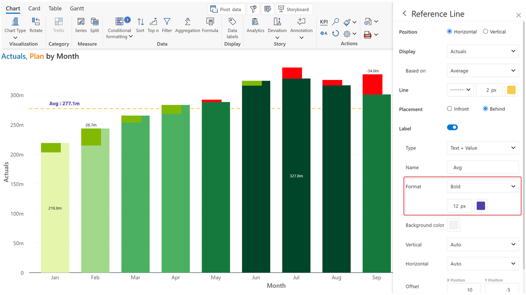

Reference Lines

#### Reference Bands

Reference bands highlight ranges or zones within visualizations:

- **Threshold Bands**: Highlighting performance zones (e.g., good/warning/critical)
- **Confidence Intervals**: Showing statistical confidence ranges
- **Seasonal Patterns**: Highlighting recurring time periods
- **Target Ranges**: Displaying acceptable performance ranges
- **Historical Comparisons**: Showing ranges from previous periods

Reference bands provide visual context that helps users interpret data within established parameters.

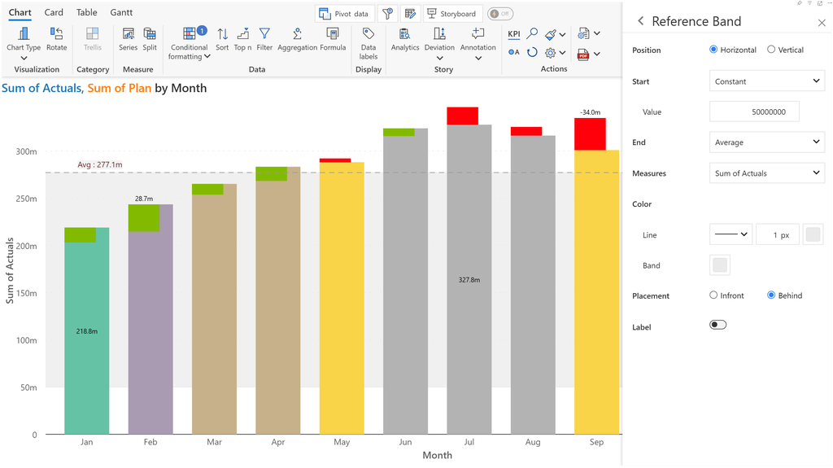

Reference bands

#### Error Bars

Error bars communicate data uncertainty and variability:

- **Standard Deviation**: Showing statistical dispersion of data
- **Standard Error**: Indicating the reliability of the mean
- **Confidence Intervals**: Displaying statistical confidence levels
- **Min/Max Ranges**: Showing the full range of observed values
- **Percentile Ranges**: Highlighting distribution characteristics

These error indicators help users understand data reliability and make more informed decisions.

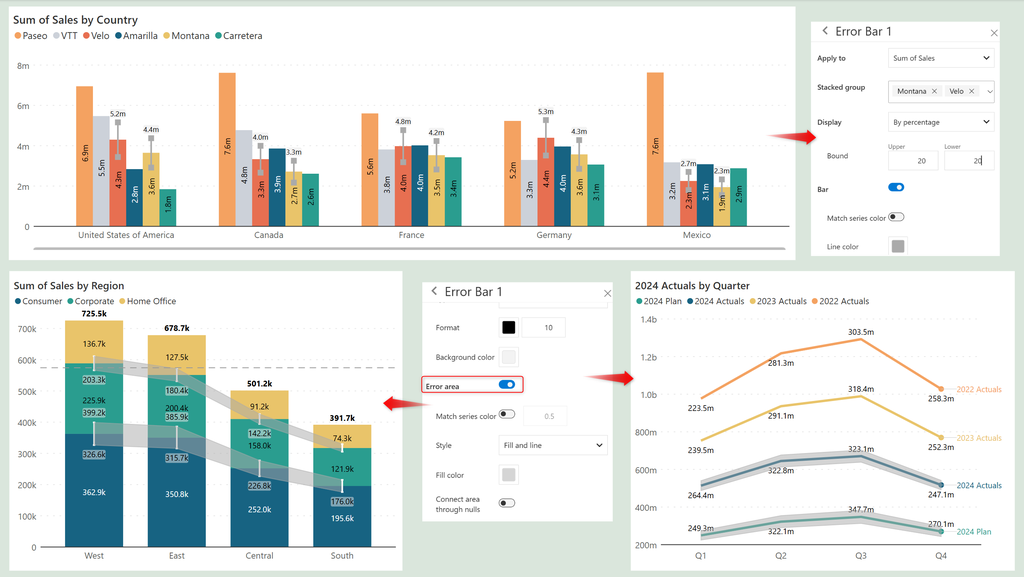

Error bars

#### Trend Lines

Trend lines reveal underlying patterns and future directions:

- **Linear Trends**: Showing consistent directional movement
- **Polynomial Trends**: Capturing more complex non-linear patterns
- **Moving Averages**: Smoothing short-term fluctuations
- **Exponential Trends**: Highlighting accelerating growth or decline
- **Forecast Extensions**: Projecting trends into future periods
- **Seasonal Adjustments**: Accounting for cyclical patterns

Trend analysis helps users distinguish between random fluctuations and meaningful directional changes.

#### Additional Series

Analytics+ allows the addition of derived or supplementary data series:

- **Calculated Series**: Derived from existing data (e.g., running totals, growth rates)
- **Benchmark Series**: Comparison data like industry averages or competitors
- **Prior Period Series**: Historical data for year-over-year or period comparisons
- **Target Series**: Planned or budgeted values for performance assessment
- **Scenario Series**: Alternative projections based on different assumptions

These additional series enhance comparative analysis and provide richer context for data interpretation.

### Data Processing Layer

The foundation layer that prepares data for visualization:

- **Data Transformation**: Conversion of raw data into visualization-ready format
- **Aggregation Engine**: Summarization of data at different levels
- **Filtering System**: Selection of relevant data subsets
- **Sorting Mechanism**: Arrangement of data in meaningful sequences
- **Calculation Engine**: Execution of visualization-specific calculations
- **Pivoting Engine**: Reorganization of data for different analytical perspectives
- **Data Binding**: Connection between data and visual elements

These layers work together to provide a seamless visualization experience that balances analytical power with ease of use.

## Storyboard Capabilities

The Storyboard mode in Analytics+ represents a significant advancement in dashboard creation within Power BI, enabling users to design comprehensive, interactive dashboards using a single visual and a single query. This approach dramatically simplifies dashboard development while maintaining sophisticated capabilities.

### Dashboard Creation Approaches

Analytics+ offers multiple paths to dashboard creation:

1. **Auto-create Reports**: Leverages AI to automatically generate dashboards based on the data structure, creating appropriate visualizations without manual intervention.
2. **Template-Based Dashboards**: Provides a library of pre-built templates for common scenarios including IBCS-compliant dashboards, financial reports, and KPI dashboards.
3. **Custom Layouts**: Enables users to build dashboards from scratch, defining the number and arrangement of elements through an intuitive interface.

The Viz-data-ink ratio slider allows users to quickly adjust the information density of dashboards, balancing visual appeal with analytical depth.

### Dashboard Elements

Storyboard mode supports a comprehensive set of dashboard elements:

- **Visualization Components**: Charts, cards, and tables with full customization capabilities
- **Navigation Controls**: Tabs, boards, and play axes for multi-page dashboards
- **Annotation System**: Comments and highlights to explain insights
- **Design Elements**: Shapes, text boxes, and images for visual organization
- **Interactive Controls**: Slicers and filters for data exploration
- **Layering System**: Z-order control for complex visual arrangements

Each element maintains its full functionality and customization options, with dedicated toolbars appearing contextually when elements are selected.

### Layout Management

The Storyboard provides sophisticated layout capabilities:

- **Drag-and-Drop Positioning**: Intuitive placement of elements
- **Resizable Containers**: Flexible sizing of dashboard components
- **Element Conversion**: Ability to switch between element types while maintaining data bindings
- **Alignment Tools**: Precise positioning of dashboard elements
- **Responsive Design**: Adaptation to different screen sizes and orientations
- **Layering Control**: Management of element stacking order

### Theming System

Analytics+ includes a comprehensive theming system for visual consistency:

- **Pre-built Themes**: Library of professionally designed color schemes
- **Theme Customization**: Ability to modify existing themes or create new ones
- **Element-Level Theming**: Application of different themes to individual dashboard elements
- **Color Palette Management**: Control of primary, secondary, and accent colors
- **Accessibility Considerations**: High-contrast themes for improved readability
- **Corporate Branding**: Support for organization-specific color schemes

The theming capabilities ensure that dashboards maintain visual consistency while allowing for creative expression and brand alignment.

## Standards-Based Approach

A distinguishing feature of the Analytics+ visualization framework is its commitment to visualization standards, particularly the International Business Communication Standards (IBCS):

### IBCS Certification

Analytics+ has achieved official IBCS certification, indicating compliance with:

- **Conceptual Aspects**: Proper message structure and content selection
- **Perceptual Aspects**: Optimized visual design for effective reception
- **Semantic Aspects**: Consistent meanings of visual elements
- **Syntactic Aspects**: Rules for proper combination of visual elements
- **Pragmatic Aspects**: Adaptation to specific business domains and situations
- **SAY Rules**: Guidelines for proper message conveyance
- **UNIFY Rules**: Standardization of concepts, terminology, and scales

This certification ensures that visualizations created with Analytics+ follow established best practices for effective business communication.

#### IBCS Implementation

Analytics+ makes IBCS compliance accessible through a simple toggle in the interface. When enabled, this toggle automatically applies IBCS standards to all visualizations:

- **Standardized Chart Types**: Conversion to IBCS-compliant chart formats
- **Semantic Notation**: Proper use of visual elements according to their meaning
- **Consistent Coloring**: Application of standard colors for actuals, plans, and variances
- **Proper Scaling**: Implementation of zero-based scales where appropriate
- **Variance Indicators**: Standardized representation of variances and deviations
- **Temporal Comparisons**: Consistent visualization of time-based comparisons
- **Hierarchical Representation**: Standardized approach to showing hierarchical data

The IBCS toggle can be applied at both the dashboard level and for individual visualization elements, allowing for flexible implementation of standards.

#### IBCS Chart Types

Analytics+ provides specialized IBCS-compliant chart types:

- **Integrated Variance Column**: Showing actuals, plans, and variances in a standardized format
- **IBCS Waterfall**: Visualizing financial statements with proper notation
- **Variance Bridge**: Connecting start and end values with standardized variance representation
- **IBCS-Compliant Tables**: Implementing proper notation in tabular formats
- **Semantic KPI Cards**: Displaying key metrics with standardized visual elements

These specialized chart types ensure that business reporting follows consistent standards that improve clarity and comparability.

### Visualization Governance

Beyond certification, Analytics+ provides a framework for visualization governance:

- **Style Libraries**: Organization-specific visual standards
- **Template Management**: Control of approved visualization templates
- **Color Palettes**: Corporate-standard color schemes
- **Terminology Standards**: Consistent naming conventions
- **Visual Hierarchy Guidelines**: Standards for information prioritization
- **Annotation Policies**: Guidelines for contextual annotations
- **Approval Workflows**: Processes for visualization review and approval

This governance framework helps organizations maintain consistent, high-quality visualizations across departments and use cases.

## The Business Impact of Advanced Visualization

The advanced visualization capabilities of Analytics+ deliver significant business impact:

- **Communication Clarity**: Clearer communication of complex business information
- **Decision Acceleration**: Faster insights leading to more timely decisions
- **Analysis Democratization**: Broader access to sophisticated analysis capabilities
- **Productivity Enhancement**: Reduced time spent creating and formatting visualizations
- **Standardization Benefits**: Consistent visualization across the organization
- **Insight Discovery**: Enhanced ability to identify patterns and outliers
- **Presentation Quality**: Professional-grade visualizations for stakeholder communication

Organizations that effectively leverage these capabilities gain a competitive advantage through improved decision-making, more efficient analytical processes, and clearer communication of business insights.

## Chapter Overview

In the following sections, we’ll explore the visualization capabilities of Analytics+ in detail:

- **Chart Type Gallery**: A comprehensive examination of the 100+ visualization types
- **IBCS Certification**: How Analytics+ implements business communication standards
- **Small Multiples Capabilities**: Techniques for comparative visualization across dimensions
- **Pivot Data Interface**: Working with hierarchical and multi-dimensional data
- **Storytelling Features**: Using annotations and reference lines to build narratives
- **On-Object Interactions**: Direct manipulation of visualization elements
- **Advanced Interaction Patterns**: Sophisticated exploration and analysis techniques
- **Storyboard Implementation**: Creating comprehensive dashboards with a single visual
- **Analytics Tools**: Leveraging reference lines, bands, and trend analysis
- **Performance Optimization**: Handling large datasets efficiently
- **Theming and Styling**: Creating visually consistent dashboards

Each section will provide practical guidance on leveraging these capabilities to create effective, professional visualizations that drive better business decisions.

The Analytics+ visualization framework represents a significant advancement in Power BI capabilities, combining ease of use with sophisticated analytical power. The five distinct modes—Chart, Card, Table, Gantt, and Storyboard—provide a comprehensive toolkit for virtually any business visualization scenario, while features like IBCS compliance, advanced analytics, and interactive customization ensure that visualizations are both effective and professional.

By the end of this chapter, you’ll have a comprehensive understanding of how Analytics+ transforms the visualization experience within Power BI, enabling you to create sophisticated, standards-compliant visualizations that communicate insights clearly and effectively.

Let’s begin by exploring the extensive chart library that forms the foundation of the Analytics+ visualization framework.

# 3.2 The Analytics+ Chart Type Gallery

Inforiver Analytics+ offers an extensive library of over 100 chart types, providing business users with the right visualization tool for virtually any analytical scenario. This comprehensive gallery goes far beyond the limited selection available in native Power BI, enabling more precise, effective visual communication. In this section, we’ll explore the diverse chart types available in Analytics+, organized by analytical purpose and usage patterns.

The Analytics+ visualization framework is designed with a “quick charts” approach that allows users to create sophisticated visualizations in just a few clicks. Each chart type comes with specific configurations and parameters that can be easily customized to meet various analytical needs. The framework supports a wide range of data visualization scenarios, from basic comparisons to complex multi-dimensional analysis.

## Comparison Charts

Comparison visualizations help users analyze similarities and differences between values across categories or time periods.

### Bar and Column Charts

The foundation of comparison visualization, these charts include:

- **Standard Column Chart**: For basic category comparison
- **Clustered Column Chart**: For comparing multiple measures across categories
- **Stacked Column Chart**: For showing both individual and total values
- **100% Stacked Column Chart**: For comparing percentage contributions
- **Horizontal Bar Chart**: For categories with long labels or many categories
- **Clustered Bar Chart**: For multi-measure comparison with better label space
- **Stacked Bar Chart**: For combining part-to-whole and comparison
- **100% Stacked Bar Chart**: For percentage composition analysis
- **Grouped Bar Chart**: For hierarchical category comparison
- **Butterfly Chart**: For comparing two related categories symmetrically
- **Diverging Bar Chart**: For highlighting positive/negative values
- **Win Loss Chart**: For depicting categories that are performing well against those that are under-performing
- **Side by Side Bar Chart**: For showing two measures side-by-side in horizontal orientation
- **Stacked Measure Chart**: For showing the contribution of each measure to the total

Column charts are particularly effective for time-based comparisons, while horizontal bar charts excel at comparing values across numerous categories or those with long descriptive labels.

#### Implementation Details

Analytics+ provides several specialized implementations of bar and column charts:

1. **Overlapped Column**: Allows multiple measures to be plotted with partial transparency to show overlapping values, ideal for comparing actual values against targets or previous periods.
2. **Cluster Column**: Plots multiple measures side by side for quick comparisons, with automatic measure configuration handled internally by Inforiver.
3. **IBCS Integrated Variance Column**: Implements IBCS standards for financial reporting, plotting actual/previous year/plan/forecast measures with relative variance indicators.

#### Customization Options

Bar and column charts in Analytics+ offer extensive customization capabilities:

- **Border Settings**: Define custom width and color for bar borders
- **Transparency Control**: Adjust the transparency of bars with options to match border color to bar color
- **Fill Patterns**: Choose between solid, outlined, and hatched patterns to distinguish between different types of data (e.g., actual vs. forecast)
- **On-object Interactions**: Click directly on bars to change measures, colors, or data label visibility
- **Measure Series Configuration**: Change chart types for specific measures, assign measures to different y-axes, or show/hide measures

### Variance Charts

Specialized for actual vs. target/plan/prior period comparisons:

- **Variance Column Chart**: Showing actual and plan with variance
- **Progressive Variance Chart**: Displaying cumulative variance over time
- **Waterfall Variance Chart**: Visualizing how variances contribute to final results
- **Variance Bridge Chart**: Connecting beginning and ending values through variances
- **Bullet Chart**: Comparing actual performance against targets and ranges
- **Thermometer Chart**: Visualizing progress toward goals
- **Progress Gauge**: Showing completion percentage with custom thresholds

These variance-focused charts are particularly valuable for financial reporting, performance monitoring, and planning/forecasting scenarios.

### Ranking Charts

Charts specifically designed to highlight rank order:

- **Ranking Bar Chart**: Horizontal bars ordered by value
- **Slope Chart**: Comparing rankings between two time periods
- **Bump Chart**: Tracking ranking changes over multiple periods
- **Lollipop Chart**: Combining bar and point for clearer ranking
- **Dot Plot**: Emphasizing position in a distribution
- **Dumbbell Chart**: Showing change between two points while maintaining rank context

These charts excel at communicating competitive position, market share rankings, and performance standings.

## Time Series Charts

Time-based visualizations reveal patterns, trends, and changes over time periods.

### Line Charts

The standard for time series analysis:

- **Basic Line Chart**: For showing trends over time
- **Multi-Line Chart**: For comparing multiple series over time
- **Step Line Chart**: For visualizing discrete changes
- **Curved Line Chart**: For smoothed trend visualization
- **Area Line Chart**: For emphasizing magnitude alongside trends
- **Stacked Area Chart**: For showing both individual contributions and totals over time
- **100% Stacked Area Chart**: For visualizing changing percentage composition
- **Ribbon Chart**: For emphasizing rank changes with width encoding
- **Range Area Chart**: For showing bounds or confidence intervals
- **Step Area Chart**: For discrete changes with magnitude emphasis

Line charts are the cornerstone of time-based analysis, providing clear visualization of trends, patterns, and relationships over time.

#### Area Chart Implementations

Analytics+ offers several specialized implementations of area charts:

1. **Standard Area Chart**: Displays the magnitude of a single measure over time with the area below the line filled.
2. **Stacked Area Chart**: Shows multiple measures stacked on top of each other, allowing users to see both individual contributions and the total.
3. **100% Stacked Area Chart**: Normalizes the data to show percentage contributions of each measure to the total.
4. **Range Area Chart**: Visualizes a range of values between upper and lower bounds, ideal for showing confidence intervals or forecast ranges.

#### Storytelling with Line Charts

Analytics+ enhances line charts with several storytelling features:

1. **Range Charts**: Visualize data ranges, confidence intervals, or forecast bands with shaded areas between upper and lower bounds.
2. **Ribbon Charts**: Show rank changes over time with varying ribbon widths, making it easy to track how different categories change positions.
3. **Reference Lines and Bands**: Add context with customizable reference elements that highlight important thresholds, targets, or time periods.
4. **Annotations**: Add explanatory text directly to the chart to guide viewers’ understanding of significant points or trends.

#### Customization Options

Line and area charts in Analytics+ offer extensive customization capabilities:

- **Line Styles**: Adjust line thickness, style (solid, dashed, dotted), and curvature
- **Point Markers**: Show or hide data points with customizable shapes and sizes
- **Area Fill**: Control opacity, gradient, and pattern for area fills
- **Interactive Tooltips**: Customize the information displayed on hover
- **Axis Configuration**: Extensive control over axis scales, labels, and gridlines
- **Highlighting**: Emphasize specific time periods or data points

### Specialized Time Series

Advanced time-based visualizations:

- **Candlestick Chart**: For showing open/high/low/close values
- **OHLC Chart**: Alternative view of open/high/low/close
- **Range Bar Chart**: For visualizing value ranges over time
- **Fan Chart**: For projected values with confidence intervals
- **Horizon Chart**: For dense time series with multiple variables
- **Calendar Heatmap**: For daily patterns over months/years
- **Cycle Plot**: For revealing both trend and cyclical patterns

These specialized time series charts address specific analytical needs beyond basic trend analysis, particularly valuable for financial data, forecasting, and seasonal pattern analysis.

## Part-to-Whole Charts

These visualizations help users understand composition and how individual components contribute to a whole.

### Standard Composition Charts

Classic approaches to showing composition:

- **Pie Chart**: For simple part-to-whole relationships
- **Donut Chart**: For part-to-whole with space for central metrics
- **Exploded Pie/Donut**: For emphasizing specific segments
- **Ring Chart**: For showing hierarchy in composition
- **Stacked Bar/Column**: For composition across categories
- **100% Stacked Bar/Column**: For percentage composition
- **Waterfall Chart**: For building up/breaking down a total
- **Mekko Chart (Marimekko)**: For showing composition with two variables
- **Cascade Chart**: For visualizing sequential additions/subtractions

While simple pie charts are often criticized in data visualization literature, Analytics+ implements best practices (limited segments, clear labeling) to ensure they are used appropriately.

### Hierarchical Composition

Visualizations for multi-level compositional data:

- **Treemap**: For hierarchical part-to-whole relationships
- **Sunburst Chart**: For visualizing hierarchical data as concentric rings
- **Icicle Chart**: For hierarchical data in a rectangular layout
- **Circle Packing**: For hierarchical grouping with size encoding
- **Nested Pie/Donut**: For two-level hierarchical composition
- **Nightingale Rose**: For cyclical compositional data

These charts are particularly valuable for visualizing hierarchical structures like organizational data, product categories, or budget allocations.

#### Treemap Charts

Treemaps in Analytics+ provide a space-efficient way to display hierarchical data using nested rectangles. Key features include:

1. **Multi-level Hierarchies**: Visualize multiple levels of hierarchical data with nested rectangles.
2. **Size and Color Encoding**: Represent values through both the size of rectangles and color intensity.
3. **Interactive Drill-down**: Click on parent rectangles to drill down into child categories.
4. **Customizable Labels**: Control the display of labels at different hierarchy levels.
5. **Border Customization**: Adjust borders between rectangles to emphasize hierarchy levels.

Implementation example: - Map dimensions to hierarchy levels (e.g., Region > Country > City) - Assign measures to determine rectangle size (e.g., Sales) - Use color intensity to represent a secondary measure (e.g., Profit Margin) - Configure label display options for each level

#### Sunburst Charts

Sunburst charts in Analytics+ display hierarchical data in a radial layout with concentric rings. Key features include:

1. **Radial Hierarchy**: Inner rings represent higher levels in the hierarchy, with outer rings showing lower levels.
2. **Angular Segments**: The size of each segment represents its proportion of the parent segment.
3. **Interactive Exploration**: Click on segments to focus on specific branches of the hierarchy.
4. **Center Text**: Display summary information in the center of the chart.
5. **Customizable Ring Width**: Adjust the width of rings to emphasize different hierarchy levels.

Implementation example: - Map dimensions to hierarchy levels (e.g., Department > Team > Employee) - Assign measures to determine segment size (e.g., Budget Allocation) - Configure color schemes to distinguish between different branches - Set up interactive tooltips to display detailed information on hover